# GENOME SEQUENCING REPORT

NDM carbapenemase analysis for hospital site XX

Report generated on 2024-08-07

## SAMPLE DETAILS

Table 1: Line list of queried isolates

| NMLPID | Pathogen | CPO gene | Sequence type (ST) | Plasmid type* | Plasmid size (kb)* | Plasmid Cluster | Epi Cluster |
| --- | --- | --- | --- | --- | --- | --- | --- |
| N23-01755 | Enterobacter cloacae | NDM-7 | 1640 | IncX3 | 47.9 | 1 |  |
| N23-01961 | Enterobacter cloacae | NDM-7 | 536 | IncX3 | 49* | 1 |  |
| N23-01962 | Enterobacter cloacae | NDM-7 | 536 | IncX3 | 50* | 1 |  |
| N23-02070 | Enterobacter cloacae | NDM-1 | 45 | IncFIB/FII | 127.8 | 2 | 1 |
| N23-02136 | Enterobacter cloacae | NDM-1 | 45 | IncFIB/FII | 124.4 | 2 | 1 |
| N23-02205 | Citrobacter freundii | NDM-1 | novel1 | IncHI2/HI2A | 254* | 3 |  |
| N23-02276 | Escherichia coli | NDM-5 | 167 | IncFIA/FIB | 137.5 | 4 |  |
| N23-02352 | Klebsiella variicola | NDM-7 | 925 | IncX3 | 47.9 | 1 | 2 |
| N23-02353 | Klebsiella variicola | NDM-7 | 925-LV1 | IncX3 | 45* | 1 | 2 |
| N23-02422 | Escherichia coli | NDM-5 | 410 | IncFIA/FIB/ Col156 | 125.6 | 5 |  |

[output cut: 24 more lines]

* Plasmid type was determined using the MOB-suite and PlasmidFinder (*Enterobacterales*) databases. Plasmid sizes with asterisks indicate the plasmid sequence is split across multiple contigs.

## ANTIMICROBIAL RESISTANCE GENES

The resistance phenotype of each isolate is shown in Figure 1 and Table 2. Genes corresponding to each phenotype are found in Appendix Table 3.

Table 2: Predicted resistance phenotype for each isolate based on antimicrobial resistance genes present in genome

| Isolate | Predicted phenotype* |
| --- | --- |
| N23-01755, N23-02912, N23-02913, N24-00693, N24-00756 | Amoxicillin, Amoxicillin+Clavulanic acid, Ampicillin, Ampicillin+Clavulanic acid, Azithromycin, Cefepime, Cefixime, Cefotaxime, Cefoxitin, Ceftazidime, Ciprofloxacin, Colistin, Doxycycline, Ertapenem,… |
| N23-01961, N23-01962 | Amoxicillin, Amoxicillin+Clavulanic acid, Ampicillin, Ampicillin+Clavulanic acid, Aztreonam, Cefepime, Cefixime, Cefotaxime, Cefoxitin, Ceftazidime, Ceftriaxone, Ciprofloxacin, Ertapenem, Imipenem, Me… |
| N23-02070, N24-00046 | Amikacin, Amoxicillin, Amoxicillin+Clavulanic acid, Ampicillin, Ampicillin+Clavulanic acid, Cefepime, Cefixime, Cefotaxime, Cefoxitin, Ceftazidime, Cephalothin, Ciprofloxacin, Doxycycline, Ertapenem, … |
| N23-02136 | Amoxicillin, Amoxicillin+Clavulanic acid, Ampicillin, Ampicillin+Clavulanic acid, Cefepime, Cefixime, Cefotaxime, Cefoxitin, Ceftazidime, Cephalothin, Ciprofloxacin, Doxycycline, Ertapenem, Imipenem, … |
| N23-02205, N23-02659, N23-03685 | Amikacin, Amoxicillin, Amoxicillin+Clavulanic acid, Ampicillin, Ampicillin+Clavulanic acid, Cefepime, Cefixime, Cefotaxime, Cefoxitin, Ceftazidime, Chloramphenicol, Ciprofloxacin, Dibekacin, Doxycycli… |
| N23-02276, N23-02657, N23-03258 | Amikacin, Amoxicillin, Amoxicillin+Clavulanic acid, Ampicillin, Ampicillin+Clavulanic acid, Azithromycin, Aztreonam, Cefepime, Cefixime, Cefotaxime, Cefoxitin, Ceftazidime, Ceftriaxone, Cephalothin, C… |
| N23-02352 | Amoxicillin, Amoxicillin+Clavulanic acid, Ampicillin, Ampicillin+Clavulanic acid, Azithromycin, Cefepime, Cefixime, Cefotaxime, Cefoxitin, Ceftazidime, Cephalothin, Ciprofloxacin, Colistin, Doxycyclin… |
| N23-02353 | Amoxicillin, Amoxicillin+Clavulanic acid, Ampicillin, Ampicillin+Clavulanic acid, Cefepime, Cefixime, Cefotaxime, Cefoxitin, Ceftazidime, Cephalothin, Colistin, Doxycycline, Ertapenem, Formaldehyde, I… |
| N23-02422 | Amoxicillin, Amoxicillin+Clavulanic acid, Ampicillin, Ampicillin+Clavulanic acid, Azithromycin, Aztreonam, Cefepime, Cefixime, Cefotaxime, Cefoxitin, Ceftazidime, Ceftriaxone, Doxycycline, Ertapenem, … |
| N23-02612, N24-00692 | Amoxicillin, Amoxicillin+Clavulanic acid, Ampicillin, Ampicillin+Clavulanic acid, Cefepime, Cefixime, Cefotaxime, Cefoxitin, Ceftazidime, Ertapenem, Imipenem, Meropenem, Piperacillin, Piperacillin+Taz… |
| N23-02613 | Amoxicillin, Amoxicillin+Clavulanic acid, Ampicillin, Ampicillin+Clavulanic acid, Cefepime, Cefixime, Cefotaxime, Cefoxitin, Ceftazidime, Ciprofloxacin, Colistin, Ertapenem, Formaldehyde, Imipenem, Me… |
| N23-02811 | Amikacin, Amoxicillin, Amoxicillin+Clavulanic acid, Ampicillin, Ampicillin+Clavulanic acid, Aztreonam, Cefepime, Cefixime, Cefotaxime, Cefoxitin, Ceftazidime, Ceftriaxone, Colistin, Ertapenem, Imipene… |
| N23-02911 | Amoxicillin, Amoxicillin+Clavulanic acid, Ampicillin, Ampicillin+Clavulanic acid, Azithromycin, Cefepime, Cefixime, Cefotaxime, Cefoxitin, Ceftazidime, Doxycycline, Ertapenem, Erythromycin, Imipenem, … |
| N23-02914 | Amoxicillin, Amoxicillin+Clavulanic acid, Ampicillin, Ampicillin+Clavulanic acid, Cefepime, Cefixime, Cefotaxime, Cefoxitin, Ceftazidime, Doxycycline, Ertapenem, Imipenem, Meropenem, Piperacillin, Pip… |
| N23-03010 | Amikacin, Amoxicillin, Amoxicillin+Clavulanic acid, Ampicillin, Ampicillin+Clavulanic acid, Azithromycin, Aztreonam, Cefepime, Cefixime, Cefotaxime, Cefoxitin, Ceftazidime, Ceftriaxone, Cephalothin, C… |
| N23-03011 | Amikacin, Amoxicillin, Amoxicillin+Clavulanic acid, Ampicillin, Ampicillin+Clavulanic acid, Cefepime, Cefixime, Cefotaxime, Cefoxitin, Ceftazidime, Chloramphenicol, Ciprofloxacin, Clindamycin, Dibekac… |
| N23-03012 | Amikacin, Amoxicillin, Amoxicillin+Clavulanic acid, Ampicillin, Ampicillin+Clavulanic acid, Aztreonam, Benzylkonium Chloride, Cefepime, Cefixime, Cefotaxime, Cefoxitin, Ceftazidime, Ceftriaxone, Cepha… |
| N23-03686 | Amoxicillin, Amoxicillin+Clavulanic acid, Ampicillin, Ampicillin+Clavulanic acid, Aztreonam, Cefepime, Cefixime, Cefotaxime, Cefoxitin, Ceftazidime, Cephalothin, Chloramphenicol, Ciprofloxacin, Doxycy… |
| N24-00047 | Amikacin, Amoxicillin, Amoxicillin+Clavulanic acid, Ampicillin, Ampicillin+Clavulanic acid, Aztreonam, Cefepime, Cefixime, Cefotaxime, Cefoxitin, Ceftazidime, Ceftriaxone, Cephalothin, Chloramphenicol… |
| N24-00755 | Amoxicillin, Amoxicillin+Clavulanic acid, Ampicillin, Ampicillin+Clavulanic acid, Cefepime, Cefixime, Cefotaxime, Cefoxitin, Ceftazidime, Ertapenem, Imipenem, Meropenem, Piperacillin, Piperacillin+Taz… |
| N24-01106 | Amikacin, Amoxicillin, Amoxicillin+Clavulanic acid, Ampicillin, Ampicillin+Clavulanic acid, Cefepime, Cefixime, Cefotaxime, Cefoxitin, Ceftazidime, Dibekacin, Ertapenem, Imipenem, Meropenem, Netilmici… |
| N24-01107 | Amoxicillin, Amoxicillin+Clavulanic acid, Ampicillin, Ampicillin+Clavulanic acid, Cefepime, Cefixime, Cefotaxime, Cefoxitin, Ceftazidime, Cephalothin, Ertapenem, Imipenem, Meropenem, Piperacillin, Pip… |
| N24-01108 | Amikacin, Amoxicillin, Amoxicillin+Clavulanic acid, Ampicillin, Ampicillin+Clavulanic acid, Aztreonam, Cefepime, Cefixime, Cefotaxime, Cefoxitin, Ceftazidime, Ceftriaxone, Cephalothin, Cephalotin, Chl… |

* Predicted phenotype is derived from the Centre for Genomic Epidemiology ResFinder database and does not represent all resistant determinants or point mutations. These phenotypes have not been completely validated in all organisms and may not represent the true phenotype for each antimicrobial.

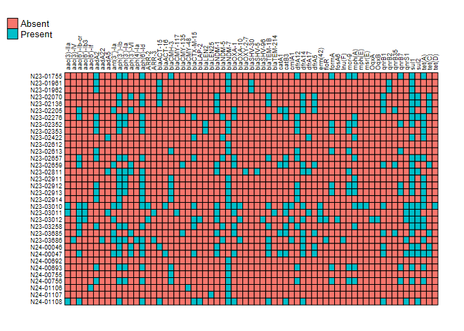

Figure 1: Resistance genes detected in genome sequencing data.

## PHYLOGENETIC CLUSTERING ANALYSIS

The *Escherichia coli* ST167 tree was conducted using N23-02657 as a reference and 98.37 % of the core genome. 2 SNVs were observed between these isolates (Figure 3).

The *Citrobacter freundii* novel1 tree was conducted using N23-02659 as the reference and 97.05 % of the core genome. 1, 20 or 21 SNVs were observed between these isolates (Figure 4).

In addition, SNV analysis was performed on the following pairs of isolates (figures not shown):

- *Klebsiella variicola* ST925: using N23-02352 as the reference, SNV analysis found 1 SNV compared to N23-02353 when using 95.63 % of the core genome. This SNV was in the *pgi* housekeeping gene which is used to call sequence types.
- *Enterobacter cloacae* ST536: using N23-01962 as the reference, SNV analysis found 1 SNV compared to N23-01961 when using 99.28 % of the core genome.

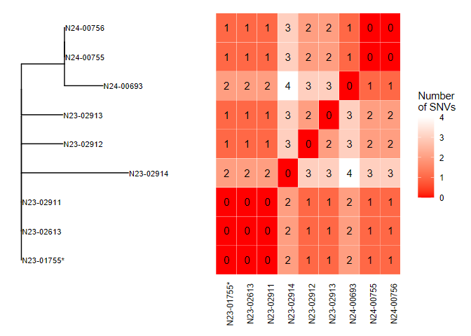

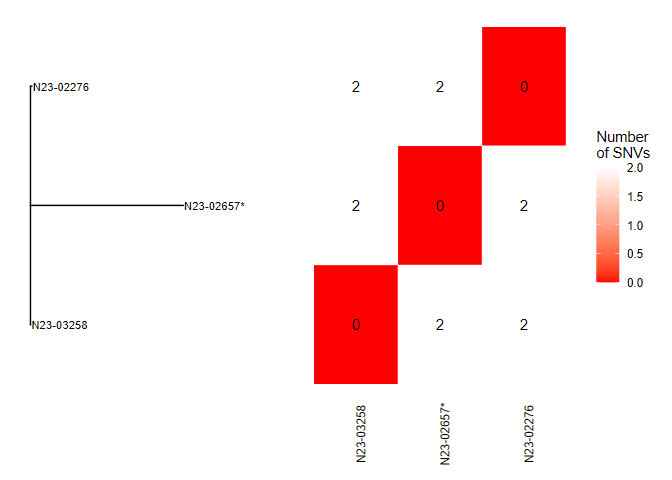

Figure 3: Maximum-Likelihood Tree (PhyML) based on SNVs from a multi-sequence alignment for *Escherichia coli* ST167 isolates. Asterisks (*) indicates the reference genome.

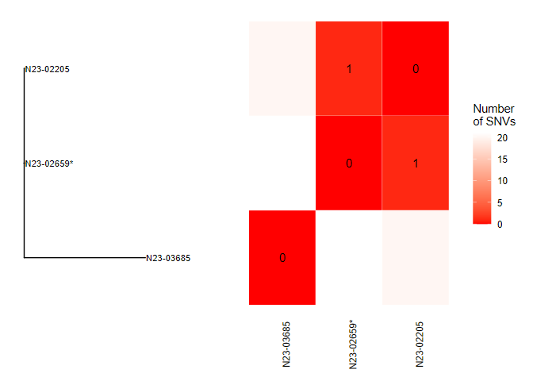

Figure 4: Maximum-Likelihood Tree (PhyML) based on SNVs from a multi-sequence alignment for *Citrobacter freundii* ST novel1 isolates. Asterisks (*) indicates the reference genome.

[figure not shown]

Figure 5: Maximum-Likelihood Tree (PhyML) based on SNVs from a multi-sequence alignment for *Enterobacter cloacae* ST45 isolates. Asterisks (*) indicates the reference genome.

## PLASMID PANGENOMES

Plasmid sequence content was compared within each plasmid cluster by using BLAST to compare to a reference plasmid (pN24-00692). Core genes are present within each plasmid whereas variable accessory genes present only in select isolates will be indicated by gaps.

The structure of the *bla*<sub>NDM-7</sub>-encoding plasmids from Plasmid Cluster #1 and Epi Cluster #3 are shown in Figure 6. Plasmid CDSs are identical.

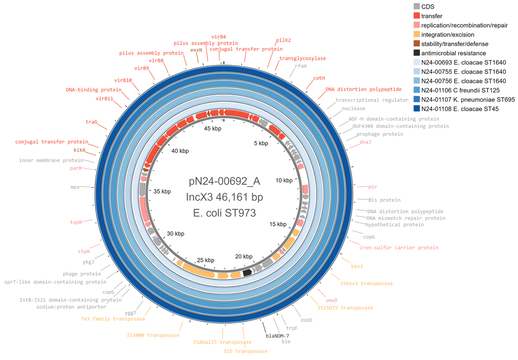

Figure 6: Plasmid structure of *bla*<sub>NDM-7</sub>-encoding IncX3 46 kb plasmids from Plasmid Cluster #1 and Epi Cluster #3.

## REPORT AUTHOR

The Antimicrobial Resistance and Nosocomial Infections (ARNI) Laboratory

Please contact us if you have any questions.

Laura Mataseje B.Sc., M.Sc.

Head of Reference Services and Applied Research, ARNI

Bacterial Pathogens, AMR and Wastewater (BPAW) Division

National Microbiology Laboratory

1015 Arlington Street, Winnipeg, Manitoba

laura.mataseje@phac-aspc.gc.ca

## DISCLAIMER

- Testing was performed, in whole or in part using a research-based test.
- Whole genome sequencing is not an ISO accredited test and results are validated and measured for quality based on in-house workflows.
- Interpretation of the results are based on in-house workflows.
- Some isolates are from the same individuals.

## DATA DICTIONARY

### Phylogenetic Analysis

- Phylogenetic analysis was conducted using the paired-end SNVPhyl pipeline v1.2.3 (https://github.com/phac-nml/snvphyl-tools) using the following parameters:
  - Minimum base coverage: 10
  - Minimum mapping quality score: 30
  - Relative SNV abundance ratio: 0.75
  - Window size for SNV density filtering: 20
- Labels, where applicable, represent: Environmental (E), Clinical (C), Sequence Type (ST), Date of isolation (YYYY-MM-DD).
- **Core**: the percent of the genome shared by all isolates that is used for phylogenetic analysis.
  - Percent core is shown for overall trees generated for each hospital as well as individual clusters.
- Approximate SNV distances are shown between branches and represent closest distance between clusters* in some cases
  - *clusters are defined as >2 isolates within a sequence type.
- Matrix data and SNV distances presented on specific clusters are true value based on sub-clustering analysis**
  - **sub-clustering was conducting buy running the SNVPhyl pipeline on specific clusters of interest using an internal reference within each cluster.
- Phylogenetic trees only shown for three or more isolates.

### Methods

- Illumina libraries were created with Nextera XT kits where paired-end 150bp indexed reads were generated on an Illumina NextSeq2000 platform using the v2.5 (300 cycles) preparation kits. Oxford Nanopore Technologies sequencing libraries were prepped using the Rapid Barcoding kit (SQK-RBK004 or SQK-RBK114.24) and R9.4.1 or R10.4.1 flowcells. Reads were basecalled using the super accurate model (SUP) with Guppy v6.5.7. *De novo* assemblies were completed using Unicycler v0.5.0 (https://github.com/rrwick/Unicycler) or Flye v2.9.2 (https://github.com/fenderglass/Flye).
- Assembled sequence data was analyzed for Multi Locus Sequence Typing (MLST), antimicrobial resistance genes and plasmid typing with a 90 % identity cut-off using StarAMR v0.10.0 (https://github.com/phac-nml/staramr) and the PointFinder database (https://bitbucket.org/genomicepidemiology/pointfinder/src/master/) (if applicable). Organism identification is based on refseqMasher (https://github.com/phac-nml/refseq_masher) or FastANI (https://github.com/ParBLiSS/FastANI).
- Plasmids were clustered using MOB-suite v3.1.5 (https://github.com/phac-nml/mob-suite) with the default secondary cluster Mash distance of 0.025.
- Where plasmids are compared to external references: Each plasmid was extracted from the assembly and queried against the PLSDB plasmid database (https://ccb-microbe.cs.uni-saarland.de/plsdb/), using MASH to identify closed known plasmids to compare against client submitted cases.
- Tn*4401* is the transposition unit on which the *bla*<sub>KPC</sub> gene is mobilized. It aids the gene in moving between plasmids and thus species. We used TETyper (https://github.com/aesheppard/TETyper) to determine the Tn*4401* variant as a method of typing KPC cases.

### Data Visualization

- All plasmid figures are generated on Proksee (https://proksee.ca/) or GView (https://server.gview.ca/) to compare CDS regions between selected plasmids.
  - **Note**: not all coding sequences are labelled in the figures.

### Definitions

- **Clonal transmission**: occurs when the same organism, indicated by species and MLST type (ex. *E. coli* ST405) and the same plasmid (if applicable), indicated by same carbapenemase and plasmid type (ex: NDM-1 IncA/C) are transmitted.
- **Plasmid transmission**: occurs when only the plasmid harbouring the resistance gene of interest is transmitted. This can occur within the same species but different MLST types (ex: plasmid NDM-1 IncA/C in *E. coli* ST405 and *E. coli* ST410) or between species (ex: plasmid NDM-1 IncA/C in *E. coli* ST405 and *K. pneumoniae* ST15).

## APPENDIX

Table 3: Predicted phenotype based on antimicrobial resistance genes present in genome

| Gene | Predicted phenotype* |
| --- | --- |
| ARR-2 | Rifampicin |
| ARR-3 | Rifampicin |
| OqxA | Benzylkonium Chloride, Cetylpyridinium Chloride, Chloramphenicol, Ciprofloxacin, Nalidixic acid, Trimethoprim |
| OqxB | Benzylkonium Chloride, Cetylpyridinium Chloride, Chloramphenicol, Ciprofloxacin, Nalidixic acid, Trimethoprim |
| aac(3)-IIa | Gentamicin, Tobramycin |
| aac(3)-IV | Gentamicin, Tobramycin |
| aac(6’)-Ib-cr | Amikacin, Ciprofloxacin, Dibekacin, Fluoroquinolone, Netilmicin, Sisomicin, Tobramycin |
| aac(6’)-Ib3 | Amikacin, Tobramycin |
| aac(6’)-If | Amikacin, Dibekacin, Netilmicin, Sisomicin, Tobramycin |
| aadA2 | Spectinomycin, Streptomycin |
| aadA22 | Spectinomycin, Streptomycin |
| aadA5 | Spectinomycin, Streptomycin |
| ant(3’’)-Ia | Streptomycin |
| aph(3’’)-Ib | Streptomycin |
| aph(3’)-Ia | Kanamycin, Lividomycin, Neomycin, Paromomycin, Ribostamycin |
| aph(3’)-Ia | Kanamycin, Neomycin |
| aph(3’)-VI | Amikacin |
| aph(4)-Ia | Hygromycin |
| aph(6)-Id | Streptomycin |
| blaACT-15 | Amoxicillin, Amoxicillin+Clavulanic acid, Ampicillin, Ampicillin+Clavulanic acid, Cefotaxime, Cefoxitin, Ceftazidime, Piperacillin, Piperacillin+Tazobactam, Ticarcillin, Ticarcillin+Clavulanic acid |
| blaACT-16 | Amoxicillin, Amoxicillin+Clavulanic acid, Ampicillin, Ampicillin+Clavulanic acid, Cefotaxime, Cefoxitin, Ceftazidime, Piperacillin, Piperacillin+Tazobactam, Ticarcillin, Ticarcillin+Clavulanic acid |
| blaCMH-3 | Unknown Beta-lactam |
| blaCMY-117 | Amoxicillin, Amoxicillin+Clavulanic acid, Ampicillin, Ampicillin+Clavulanic acid, Cefotaxime, Cefoxitin, Ceftazidime, Piperacillin, Piperacillin+Tazobactam, Ticarcillin, Ticarcillin+Clavulanic acid |
| blaCMY-135 | Amoxicillin, Amoxicillin+Clavulanic acid, Ampicillin, Ampicillin+Clavulanic acid, Cefotaxime, Cefoxitin, Ceftazidime, Piperacillin, Piperacillin+Tazobactam, Ticarcillin, Ticarcillin+Clavulanic acid |
| blaCMY-48 | Amoxicillin, Amoxicillin+Clavulanic acid, Ampicillin, Ampicillin+Clavulanic acid, Cefotaxime, Cefoxitin, Ceftazidime, Piperacillin, Piperacillin+Tazobactam, Ticarcillin, Ticarcillin+Clavulanic acid |
| blaCTX-M-15 | Amoxicillin, Ampicillin, Aztreonam, Cefepime, Cefotaxime, Ceftazidime, Ceftriaxone, Piperacillin, Ticarcillin |
| blaLAP-2 | Amoxicillin, Ampicillin, Cephalotin, Piperacillin, Ticarcillin |
| blaLEN2 | Amoxicillin, Ampicillin, Cephalothin, Piperacillin, Ticarcillin |
| blaLEN25 | Amoxicillin, Ampicillin, Cephalothin, Piperacillin, Ticarcillin |
| blaNDM-1 | Amoxicillin, Amoxicillin+Clavulanic acid, Ampicillin, Ampicillin+Clavulanic acid, Cefepime, Cefixime, Cefotaxime, Cefoxitin, Ceftazidime, Ertapenem, Imipenem, Meropenem, Piperacillin, Piperacillin+Taz… |
| blaNDM-5 | Amoxicillin, Amoxicillin+Clavulanic acid, Ampicillin, Ampicillin+Clavulanic acid, Cefepime, Cefixime, Cefotaxime, Cefoxitin, Ceftazidime, Ertapenem, Imipenem, Meropenem, Piperacillin, Piperacillin+Taz… |
| blaNDM-7 | Amoxicillin, Amoxicillin+Clavulanic acid, Ampicillin, Ampicillin+Clavulanic acid, Cefepime, Cefixime, Cefotaxime, Cefoxitin, Ceftazidime, Ertapenem, Imipenem, Meropenem, Piperacillin, Piperacillin+Taz… |
| blaOXA-1 | Amoxicillin, Amoxicillin+Clavulanic acid, Ampicillin, Ampicillin+Clavulanic acid, Cefepime, Piperacillin, Piperacillin+Tazobactam |
| blaOXA-10 | Amoxicillin, Ampicillin, Aztreonam, Piperacillin, Piperacillin+Tazobactam |
| blaOXY-2-7 | Amoxicillin, Amoxicillin+Clavulanic acid, Ampicillin, Ampicillin+Clavulanic acid, Cefotaxime, Cefoxitin, Ceftazidime, Piperacillin, Piperacillin+Tazobactam, Ticarcillin, Ticarcillin+Clavulanic acid |
| blaSHV-30 | Amoxicillin, Ampicillin, Aztreonam, Cefepime, Cefotaxime, Ceftazidime, Ceftriaxone, Piperacillin, Ticarcillin |
| blaSHV-5 | Amoxicillin, Ampicillin, Aztreonam, Cefepime, Cefotaxime, Ceftazidime, Ceftriaxone, Piperacillin, Ticarcillin |
| blaSHV-96 | Unknown Beta-lactam |
| blaTEM-1B | Amoxicillin, Ampicillin, Cephalothin, Piperacillin, Ticarcillin |
| blaTEM-214 | Unknown Beta-lactam |
| catA1 | Chloramphenicol |
| catB3 | Chloramphenicol |
| cmlA1 | Chloramphenicol |
| dfrA12 | Trimethoprim |
| dfrA14 | Trimethoprim |
| dfrA17 | Trimethoprim |
| dfrA5 | Trimethoprim |
| erm(42) | Clindamycin, Erythromycin, Lincomycin, Pristinamycin IA, Quinupristin, Virginiamycin S |
| floR | Chloramphenicol, Florfenicol |
| formA | Formaldehyde |
| fosA6 | Fosfomycin |
| lnu(F) | Lincomycin |
| mcr-9 | Colistin |
| mph(A) | Azithromycin, Erythromycin, Spiramycin, Telithromycin |
| mph(E) | Erythromycin |
| msr(E) | Azithromycin, Erythromycin, Pristinamycin IA, Quinupristin, Virginiamycin S |
| qnrB1 | Ciprofloxacin |
| qnrB2 | Ciprofloxacin |
| qnrB35 | Ciprofloxacin |
| qnrB7 | Ciprofloxacin |
| qnrS1 | Ciprofloxacin |
| sul1 | Sulfamethoxazole |
| sul2 | Sulfamethoxazole |
| tet(A) | Doxycycline, Tetracycline |
| tet(C) | Doxycycline, Tetracycline |
| tet(D) | Doxycycline, Tetracycline |

* Predicted phenotype is derived from the Centre for Genomic Epidemiology ResFinder database and does not represent all resistant determinants or point mutations. These phenotypes have not been completely validated in all organisms and may not represent the true phenotype for each antimicrobial.